# Praca domowa 6

**Autor: Paulina Tomaszewska**

W ramach pracy domowej przeanalizuję wykresy ALE i PDP w zadaniu Uplift.

*Z uwagi na to, że modele w ramach projektu zostały wytrenowane na danych w formacie numpy.array a nie pandas.DataFrame wykresy generowane z wykorzystaniem pakietu Dalex jako tytuły mają kolejne liczby porządkowe a nie nazwy stricte zmiennych. Zapewne w kolejnych wersjach pakietu zostanie dodana możliwość dodania jako parametru listy z nazwami kolumn co rozwiązałoby wspomnianą niedogodność.*

Dlatego poniżej prezentuję sposób mapowania tytułów wykresów na rzeczywiste nazwy kolumn w oryginalnych danych (wiedza ta będzie niezbędna w celu zrozumienia wyjaśnień).

0: recency

1: history

2: mens

3: womens

4: zip_code_Surburban

5: zip_code_Rural

6: zip_code_Urban

7: newbie

8: channel_Phone

9: channel_Web

10: channel_Multichannel

11: segment

# Model oparty o XGBoost

Pierwszy model, który poddam w analizie to nasz finalny model wykorzystywany w projekcie. W ramach niego korzystamy z odejmowania prawdopodobieństw generowanych przez XGBoost Classifier przy założeniu że raz dana osoba została poddana pewnej akcji (treatment) natomiast za drugim razem nie.

Poniżej prezentuję wykresy prezentujące jakość predykcji na zbiorze treningowym i testowym. Widać, że model jest trochę lepszy od rozwiązania losowego. Pomimo zastosowania wyszukanych technik strojenia parametrów nie udało się bardziej zwiększyć pola pod krzywą Gain.

```
best train uplift score = 0.03933381220515971
best valid uplift score = 0.017943163838862273
```

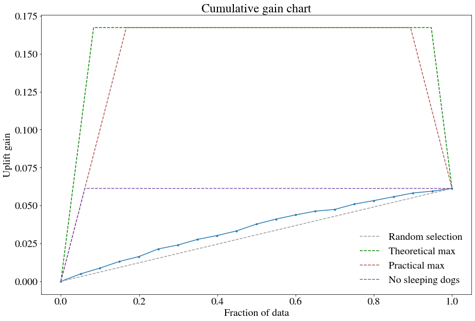

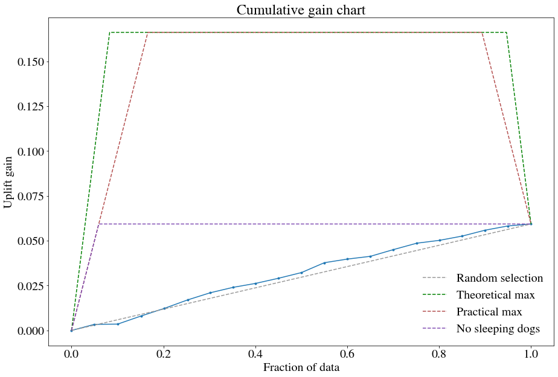

```python
best_model = local_search_xgb(X_train, Y_train, X_valid, Y_valid, treatment_col, just_get_model=True)
check_uplift_diff(best_model, "best", X_train, Y_train, X_valid, Y_valid, treatment_col)
```

Do tworzenia wyjaśnień wykorzystałam pakiet Dalex.

## PDP

```python
import dalex
from model import predict_treatment

def calc_uplift_filled(model, x):
    treatment_col=11
    x = np.array(x)
    return predict_treatment(model, treatment_col, 1)(x) - predict_treatment(model, treatment_col, 0)(x)

exp = dalex.Explainer(best_model, X_train,Y_train, label = "xgboost", predict_function = calc_uplift_filled)

partial=exp.model_profile(type='partial')
```

```
Preparation of a new explainer is initiated

data is converted to pd.DataFrame, columns are set as string numbers
  -> data              : 51200 rows 12 cols
  -> target variable   : 51200 values
  -> model_class       : xgboost.sklearn.XGBClassifier (default)
  -> label             : xgboost
  -> predict function  : <function calc_uplift_filled at 0x00000156F9224708> will be used
  -> predicted values  : min = 0.01510486, mean = 0.05763817, max = 0.18978107
  -> residual function : difference between y and yhat (default)
  -> residuals         : min = -0.1897810697555542, mean = 0.0891391786283566, max = 0.9775854591280222
  -> model_info        : package xgboost

A new explainer has been created!
```

```python
def calc_uplift_filled(model, x):
    treatment_col=11
    x = np.array(x)
    return predict_treatment(model, treatment_col, 1)(x) - predict_treatment(model, treatment_col, 0)(x)

exp = dalex.Explainer(best_model, X_train,Y_train, label = "xgboost", predict_function = calc_uplift_filled)

partial=exp.model_profile(type='partial')
partial.plot()
```

```
Preparation of a new explainer is initiated

data is converted to pd.DataFrame, columns are set as string numbers
  -> data              : 51200 rows 12 cols
  -> target variable   : 51200 values
  -> model_class       : xgboost.sklearn.XGBClassifier (default)
  -> label             : xgboost
  -> predict function  : <function calc_uplift_filled at 0x00000206E38D6EE8> will be used
  -> predicted values  : min = 0.01510486, mean = 0.05763817, max = 0.18978107
  -> residual function : difference between y and yhat (default)
```

```
  -> residuals         : min = -0.1897810697555542, mean = 0.0891391786283566, max = 0.9775854591280222
  -> model_info        : package xgboost

A new explainer has been created!
```

[interactive chart not shown]

Pierwszym stworzonym wykresem jest PDP. Wyraźnie widać, że wykresy dla zmiennych niebinarnych mają skomplikowane kształty - szczególnie odnosi się to do zmiennej "1", która określa sumę pieniędzy wydaną przez konkretną osobę w ciągu ostatnich 12 miesięcy. Co ciekawe widać, że dla najmniejszych wartości zmiennej *history* (z zakresu 30 dolarów - 130 dolarów) krzywa jest pozioma tj. niewrażliwa na zmienność tego parametru. Natomiast dla wartości *history* o wartości 144 dolarów następuje dziwny gwałtowny spadek uplift. Dla kolejnych wartości zmiennej *history* obserwowane są znaczne fluktuacje. Kolejny silny spadek wartości uplift jest dla wartości 438 dolarów. Warto jednak podkreślić że oprócz gwałtownych spadków obserwowany jest też wzrost uplift - dla wartości *history* od 880 USD do 1005 USD. Natępnie krzywa opada do wartosci 1220$ i się praktycznie stabilizuje. Kształt tej krzywej jest dla mnie zaskakujący - nie spodziewałam się tak gwałtownych zmian w kontekście predykcji.

Innym ciekawym wykresem jest ten dla zmiennej "0" (określa, ile miesięcy minęło od ostatnich zakupów danego klienta). Tutaj również widać wiele ekstremów lokalnych, jednak funkcja jest gładka. Widać wyraźnie trend malejący tj. Największy uplift jest generalnie dla klientów którzy niedawno robili zakupy, co jest zgodne z intuicją. Są to klienci, którzy z naszą firmą są najbardziej związani a więc mamy na nich największą siłę oddziaływania. Zastanawiający jest jednak wzrost uplift pomiędzy wartości 11 a 12 zmiennej "0".

W przypadku pozostałych zmiennych (są binarne) nie obserwowany jest duży wpływ na predykcje - krzywe są prawie płaskie. Różnice w uplift między różnymi wariantami wartości tych zmiennych są w granicach 1%.

## ALE

```python
ale=exp.model_profile(type='accumulated')
```

```
The Panel class is removed from pandas. Accessing it from the top-level namespace will also be removed in the next version
```

```python
ale.plot()
```

[interactive chart not shown]

Warto podkreślić, że wykres ALE jest taki sam jak PDP, co świadczy o tym że w modelu nie ma interakcji.

# Model oparty o klasyfikator Naive Bayes

Postanowiłam także sprawdzić jak będą wyglądać wykresy PDP i ALE dla modelu do szacowania Uplift opartego na Naive Bayes. W tym wypadku jest model który nie został poddany tak zaawansowanemu strojeniu parameterów jak wcześniej XGBoost z uwagi na swoją prostą konstrukcję. Jestem ciekawa jak taki charakter będą miały krzywe wygenerowane z użyciem takiego prostego modelu. **Moja hipoteza: podejrzewam, że z uwagi na prostotę modelu, krzywe nie będą miały wiele ekstremów lokalnych - będą bardziej monotoniczne.**

Zanim przejdę jednak do testowania mojej hipotezy sprawdzę czy klasyfikator oparty o Naive Bayes sprawdzę czy jego jakość jest satysfakcjonująca. Wykresy poniżej pokazują, że mają one zbliżony wygląd do tych stworzonych w oparciu o XGBoost. Co ciekawe wartość metryki okreslającej pole pod krzywą w przypadku zbioru treningowego jest blisko 4 razy mniejsze w przypadku Naive Bayes jednak w przypadku zbioru testowego wynik z użyciem Naive Bayes jest o jeden punkt procentowy wyższy niż dla XGBoost.

```
best train uplift score = 0.009587264988251047
best valid uplift score = 0.025953556785552414
```

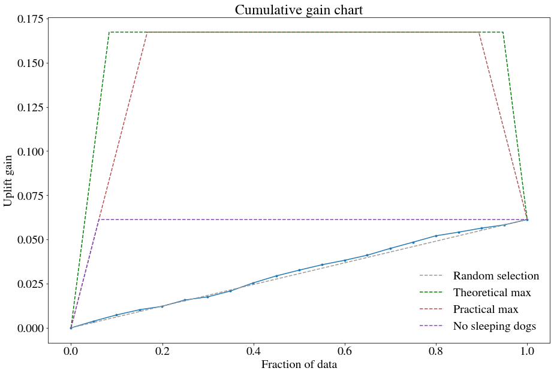

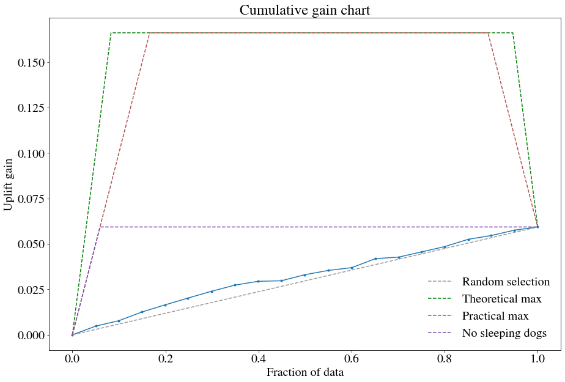

```python
check_uplift_diff(nb, "best", X_train, Y_train, X_valid, Y_valid, treatment_col)
```

```python
from sklearn.naive_bayes import GaussianNB
nb=GaussianNB().fit(X_train, Y_train)
exp = dalex.Explainer(nb, X_train,Y_train, predict_function = calc_uplift_filled)
```

```
Preparation of a new explainer is initiated

data is converted to pd.DataFrame, columns are set as string numbers
  -> data              : 51200 rows 12 cols
  -> target variable   : 51200 values
  -> model_class       : sklearn.naive_bayes.GaussianNB (default)
  -> label             : not specified, model's class short name is taken instead (default)
  -> predict function  : <function calc_uplift_filled at 0x00000156F9224708> will be used
  -> predicted values  : min = 9.51568742646458e-06, mean = 0.0817726296911341, max = 0.18599801165820218
  -> residual function : difference between y and yhat (default)
  -> residuals         : min = -0.18599801165820218, mean = 0.06500471405886592, max = 0.9998027076156947
  -> model_info        : package sklearn

A new explainer has been created!
```

## PDP

```python
exp = dalex.Explainer(nb, X_train,Y_train, predict_function = calc_uplift_filled)
partial=exp.model_profile(type='partial')
partial.plot()
```

[interactive chart not shown]

Zgodnie z moją hipotezą wykres PDP jest krzywą znacznie bardziej gładka (dotyczy to zmiennej "0" i "1") natomiast w przypadku zmiennych binarnych nadal mało one wnoszą - widoczny jest ich mały wpływ. Największy kat nachylenia krzywych w przypadku zmiennych binarnych jest obserwowany dla zmiennej "10" (channel Multichannel) i "5" (zip_code_Rural).

W przypadku zmiennej "0" jest to wykres liniowy o ujemnych współczynniku kierunkowym - można powiedzieć że podobny trend przedstawiał wykres PDP w przypadku XGBoosta jednak w przypadku tamtego modelu wychwycone były niusane w danych czego odzwierciedlenieniem były ekstrema lokalne.

W przypadku zmiennej "1" również można się dopatrzeć podobieństw między dwoma modelami - XGBoost a Naive Bayes, tzn. wartość uplift rośnie aż do osiągnięcia maksimum a następnie maleje. Największa różnica jednak dotyczy największych wartości zmiennej history - dla XGBoost wykres się wypłaszcza podczas gdy dla Naive Bayes wykres gwałtownie opada.

Różnice w wykresach dla różnych modeli:

- w przypadku zmiennej "6" (zip_code_Urban) wykres dla XGBoost jest rosnący podczas gdy dla Naive Bayes jest lekko malejący
- dla zmiennej "8" (channel_Phone) sytuacja przedstawia się analogicznie jak dla zmiennej "6"

## ALE

```python
ale=exp.model_profile(type='accumulated')
ale.plot()
```

```
The Panel class is removed from pandas. Accessing it from the top-level namespace will also be removed in the next version
```

[interactive chart not shown]

```python
Ponownie wykres ALE pokrywa się z PDP - wniosek: nie ma w modelu interakcji.
```

## Podsumowanie:

Zastosowane model znacznie różnią się budową (także stopniem skomplikowania), jednak mają zbliżoną jakość. Wykresy ALE i PDP są zbliżone w kontekście zmiennych binarnych (ich wpływ na predykcje jest mały). Natomiast dla zmiennych niebinarnych: "0" i "1" wykresy wygenerowane w oparciu o Naive Bayes są znacznie bardziej gładkie niż w przypadku XGBoost. Co ciekawe w przypadku obu modeli wykresy ALE i PDP się pokrywają - brak interakcji w modelu.